# Functional Programming

FSH 507 Fall 2019

Dan Ovando and Mark Sorel

2019-10-14

# Acknowledgements

This background material on functions is adapted from Hadley Wickham’s Advanced R (2nd eddition). See that book for more details

# Function fundamentals

- Three components: **arguments, body, and environment**.

Except “primitive” base functions that are implemented purely in C.

- Functions are objects, just as vectors are objects.

# A function has three parts

- The `formals()`, the list of arguments that control how you call the function.
- The `body()`, the code inside the function.
- The `environment()`, the data structure that determines how the function finds the values associated with the names.

Can return anything: including a list of lots of things, or a function.

# Environments

- The environment is specified implicitly, based on *where* you defined the function.
- The function environment always exists, but it is only printed when the function isn’t defined in the global environment.

# Environments cont.

```r
f02 <- function(x, y) {
  # A comment
  x + y
}
formals(f02)
```

[output not shown]

```r
body(f02)
```

```
## {
##     x + y
## }
```

```r
environment(f02)
```

```
## <environment: R_GlobalEnv>
```

# Environments cont. - Default Values

You can assign defaul values to function arguments (formals)

```r
foo <- function(x = 2, y =  "apples") {
  paste(x,y)
}
formals(foo)
```

```
## $x
## [1] 2
##
## $y
## [1] "apples"
```

```r
foo()
```

```
## [1] "2 apples"
```

# Getting things out of functions

By default, functions return the last thing inside them.

What will `result` contain?

```r
foo <- function(x){

  y = x^2

  print("hello")
}

result <- foo(2)
```

```
## [1] "hello"
```

```r
result
```

```
## [1] "hello"
```

# Getting things out of functions

You can overwrite this behavior by calling `return` explicitly

```r
foo <- function(x){

  y = x^2

  print("hello")

  return(y)

}

result <- foo(2)
```

```
## [1] "hello"
```

```r
result
```

```
## [1] 4
```

# Getting things out of functions

Want multiple outputs? Make it a list

```r
foo <- function(x){


  y = x^2

  z <- rep(x,2)

  w <- data.frame(x = z, y = y)

  return(list(y = y,
              z = z,
              w = w))

}

result <- foo(2)
result
```

```
## $y
## [1] 4
##
## $z
## [1] 2 2
##
## $w
##   x y
## 1 2 4
## 2 2 4
```

# First-class functions

R functions are objects. You create a function object with `function` and bind it to a name with `<-`:

```r
f01 <- function(x) {
  sin(1 / x ^ 2)
}
```

If you don’t bind a function to a name, you get an **anonymous function**. (`~` also is used to call anonymous functions in many places)

```r
lapply(mtcars, function(x) length(unique(x)))
Filter(function(x) !is.numeric(x), mtcars)
```

You can put functions in a list: Everything’s an object

```r
funs <- list(
  half = function(x) x / 2,
  double = function(x) x * 2
)
funs$double(10)
```

```
## [1] 20
```

# Lexical scoping

**scoping**: finding the value associated with a name.

what will the following code return, 10 or 20?

```r
x <- 10
g01 <- function() {
  x <- 20
  x
}
g01()
```

# Lexical scoping

**scoping**: finding the value associated with a name.

what will the following code return, 10 or 20?

```r
x <- 10
g01 <- function() {
  x <- 20
  x
}
g01()
```

```
## [1] 20
```

# Lexical scoping cont.

R uses **lexical scoping**: it looks up the values of names based on how a function is defined

R’s lexical scoping follows four primary rules:

- Name masking
- Functions versus variables
- A fresh start
- Dynamic lookup

# Name masking

names defined inside a function mask names defined outside

```r
x <- 10
y <- 20
g02 <- function() {
  x <- 1
  y <- 2
  c(x, y)
}
g02()
```

```
## [1] 1 2
```

# Name masking cont.

If a name isn’t defined inside a function, R looks one level up.

```r
x <- 2
g03 <- function() {
  y <- 1
  c(x, y)
}
g03()
```

```
## [1] 2 1
```

And this doesn’t change the previous value of y

```r
y
```

```
## [1] 20
```

The same rules apply if a function is defined inside another function

# A fresh start

when a function is called a new environment is created to host its execution. Each invocation is completely independent.

```r
g11 <- function() {
  if (!exists("a")) {
    a <- 1
  } else {
    a <- a + 1
  }
  a
}
g11()
```

```r
g11()
```

# A fresh start

when a function is called a new environment is created to host its execution. Each invocation is completely independent.

```r
g11 <- function() {
  if (!exists("a")) {
    a <- 1
  } else {
    a <- a + 1
  }
  a
}
g11()
```

```
## [1] 1
```

```r
g11()
```

```
## [1] 1
```

# Lazy evaluation

function arguments are only evaluated if accessed

This allows you to include potentially expensive computations in function arguments that will only be evaluated if needed

# Default arguments

Default arguments are evaluated inside the function, so seemingly identical calls can yield different results. An extreme example:

```r
h05 <- function(x = ls()) {
  a <- 1
  x
}
# ls() evaluated inside h05:
h05()
```

```
#> [1] "a" "x"
```

```r
# ls() evaluated in global environment:
h05(ls())
```

```
#> [1] "h05"
```

# `...` (dot-dot-dot)

Functions can have a special argument `...` (pronounced dot-dot-dot). With it, a function can take any number of additional arguments.

You can capture the elements of `...` using `list`

```r
i00 <- function(x,y,...){

  pars = list(...)

  print(pars)

}

i00(1,2,"hello","world")
```

```
## [[1]]
## [1] "hello"
##
## [[2]]
## [1] "world"
```

# `...` (dot-dot-dot)

You can also use `...` to pass those additional arguments on to another function.

```r
i01 <- function(y, z) {
  list(y = y, z = z)
}

i02 <- function(x, ...) {
  i01(...)
}

str(i02(x = 1, y = 2, z = 3))
```

```
## List of 2
##  $ y: num 2
##  $ z: num 3
```

# Function forms

> To understand computations in R, two slogans are helpful:
> - Everything that exists is an object.
> - Everything that happens is a function call.

> — John Chambers

# Functional programming (style)

- Decompose the problem into isolated functions.
- Each function is simple and straightforward.
- Complexity is handled by composing functions.
- A functional style is easier to automatically optimise or parallelise.

# Pure functions

A function is pure if it satisfies two properties:

- The output only depends on the inputs, i.e. if you call it again with the same inputs, you get the same outputs.
  - This is why you should avoid global variables - outputs can depend on things not explicitly passed to the function
  - Excludes functions like `runif()`, `read.csv()`, or `Sys.time()` that can return different values.
- The function has no side-effects, like changing the value of a global variable, writing to disk, or displaying to the screen. This excludes functions like `print()`, `write.csv()` and `<-`.

# Pure functions

A function is pure if it satisfies two properties:

- The output only depends on the inputs, i.e. if you call it again with the same inputs, you get the same outputs.
  - Excludes functions like `runif()`, `read.csv()`, or `Sys.time()` that can return different values.
- The function has no side-effects, like changing the value of a global variable, writing to disk, or displaying to the screen. This excludes functions like `print()`, `write.csv()` and `<-`.

Pure functions are easier to reason about, but can’t do things like generate random numbers or read files from disk.

Partitioning code into functions that are either extremely pure or extremely impure tends to lead to code that is easier to understand and extends to new situations.

# Functionals

> To become significantly more reliable, code must become more transparent. In particular, nested conditions and loops must be viewed with great suspicion. Complicated control flows confuse programmers. Messy code often hides bugs.

> — Bjarne Stroustrup

A **functional** is a function that takes a function as an input and returns a vector as output.

Common functionals: `lapply()`, `apply()`, `tapply()`; purrr’s `map()`; `integrate()` and `optim()`.

# Functionals

> To become significantly more reliable, code must become more transparent. In particular, nested conditions and loops must be viewed with great suspicion. Complicated control flows confuse programmers. Messy code often hides bugs.

> — Bjarne Stroustrup

A **functional** is a function that takes a function as an input and returns a vector as output.

Common functionals: `lapply()`, `apply()`, `tapply()`; purrr’s `map()`; `integrate()` and `optim()`.

- An alternative to for loops.
- When you recognise the functional you immediately know why it’s being used.
- Switching to functionals is typically a pattern matching exercise. You look at the for loop and find a functional that matches the basic form.

# Non-standard evaluation

Suppose you wanted to write a function like this: why won’t this work?

```r
foo <- function(data,colorvar){

  data %>%
    ggplot(aes(x,y, color = colorvar)) +
    geom_point()

}
```

# Tidy Evaluation

We don’t have time to explain this, but the solution is [tidy evaluation](https://tidyeval.tidyverse.org/index.html)

Also see [here](https://dplyr.tidyverse.org/articles/programming.html) and

[here](https://www.tidyverse.org/articles/2018/07/ggplot2-tidy-evaluation/)

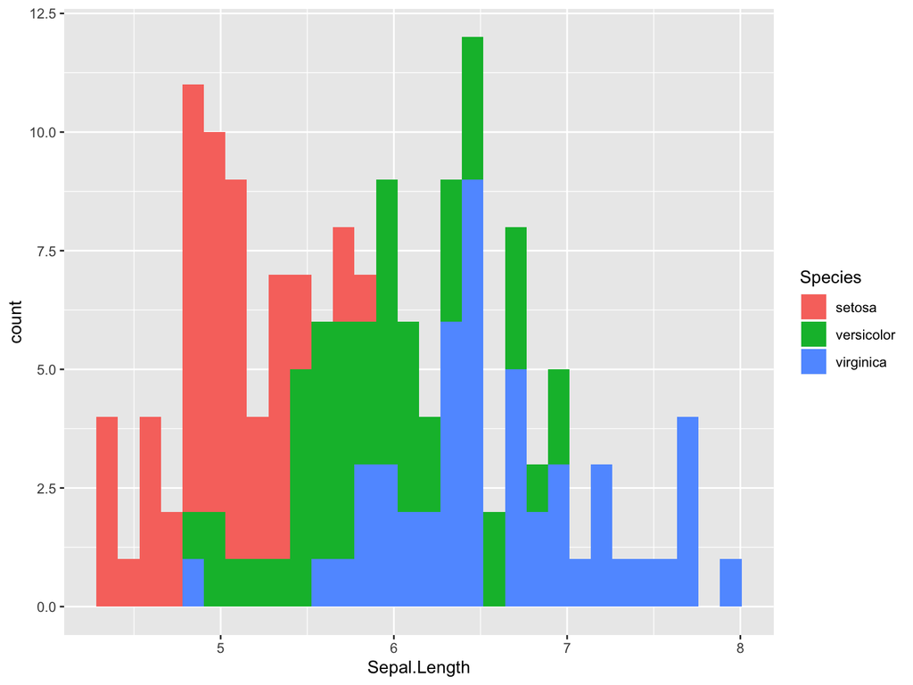

```r
foo <- function(data, histvar, fillvar) {

  histvar <- enquo(histvar) # captures what the user typed

  fillvar <- enquo(fillvar)

  # !! (bang-bang) evaluates the contents of the enquoted variable
    data %>%
    ggplot(aes(!!histvar, fill = !!fillvar)) +
    geom_histogram()

}


foo(iris, Sepal.Length, Species)
```

- Non-standard evaluation
  - e.g. passing grouping variables as a variable to a function
  - https://tidyeval.tidyverse.org/
  - https://github.com/rstudio/cheatsheets/raw/master/tidyeval.pdf

# A few other resources

- https://speakerdeck.com/jennybc/purrr-workshop?slide=6
- https://jennybc.github.io/purrr-tutorial/
- http://adv-r.had.co.nz/Functions.html